# Reproducible Research [Coursera]: Assignment 1

Hasintha Attanayake

16 June 2016

**The following document consists of secondary headings as dictated by the assignment instructions and tertiary headings for subdivisions of assigned tasks**  
## Loading and preprocessing the data  
### Loading the raw data

The file ‘activity.csv’ should be located within main repository / working directory of R markdown file and will be imported into the work environment using **read.csv()**

```r
activity <- read.csv('activity.csv', header = TRUE)
```

### Preprocessing the raw data

The raw dataframe *activity* will be simplified by removing all **NA** values with the **na.omit** function. (missing values ignored)

```r
activity_processed <- na.omit(activity)
```

*For the following two parts of the assingment the preprocessed simplified data is used*

### What is mean total number of steps taken per day?

**1. Calculate the total number of steps taken each day**

```r
library(plyr)
summary_steps <- ddply(activity_processed,.(date),summarise, steps_per_day = sum(steps))
head(summary_steps)
```

```
##         date steps_per_day
## 1 2012-10-02           126
## 2 2012-10-03         11352
## 3 2012-10-04         12116
## 4 2012-10-05         13294
## 5 2012-10-06         15420
## 6 2012-10-07         11015
```

**2. Make a histogram of the total number of steps taken each day**

Plotted using basic function with breaks (size bins) in the frequency histogram of 5 and 20 for comparison.

**5 size bins:**

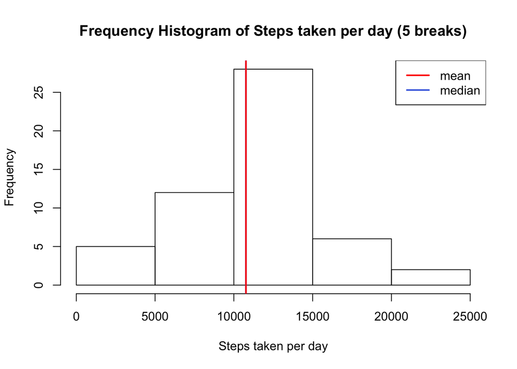

```r
hist(summary_steps$steps_per_day, breaks = 5, xlab = "Steps taken per day", main ="Frequency Histogram of Steps taken per day (5 breaks)")
abline(v = median(summary_steps$steps_per_day),col = "royalblue", lwd = 2)
abline(v = mean(summary_steps$steps_per_day),col = "red", lwd = 2)
legend(x = "topright", c("mean","median"), col = c("red","royalblue"), lwd = c(2,2))
```

**20 size bins:**

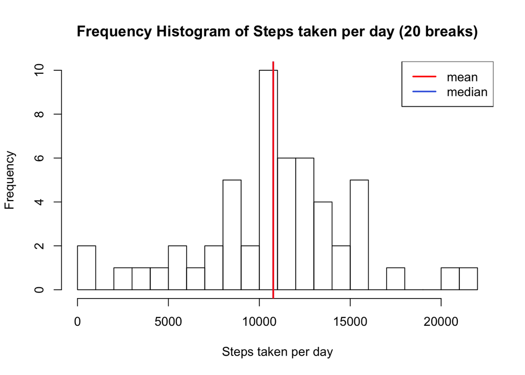

```r
hist(summary_steps$steps_per_day, breaks = 20, xlab = "Steps taken per day", main ="Frequency Histogram of Steps taken per day (20 breaks)")
abline(v = median(summary_steps$steps_per_day),col = "royalblue", lwd = 2)
abline(v = mean(summary_steps$steps_per_day),col = "red", lwd = 2)
legend(x = "topright", c("mean","median"), col = c("red","royalblue"), lwd = c(2,2))
```

**3. Calculate and report the mean and median of the total number of steps taken per day**

```r
mean_steps <- mean(summary_steps$steps_per_day)
median_steps <- median(summary_steps$steps_per_day)
```

```r
mean_steps
```

```
## [1] 10766.19
```

```r
median_steps
```

```
## [1] 10765
```

```r
total_steps <- sum(activity_processed$steps)
total_days <- length(unique(activity_processed$date))
validated_mean <- total_steps/total_days
```

```r
validated_mean
```

```
## [1] 10766.19
```